# CELLector App: a front end to CELLector for Genomics Guided Selection of Cancer in vitro models

Tutorial and example study cases

Hanna Najgebauer and Francesco Iorio

2020-04-09

[figure not shown]

## Introduction

CELLector App is a user friendly interface to CELLector: a computational tool assisting experimental scientists in the selection of the most clinically relevant cancer cell lines to be included in a new in-vitro study (or to be considered in a retrospective study), in a patient-genomic guided fashion.

CELLector combines methods from graph theory and market basket analysis; it leverages tumour genomics data to explore, rank, and select optimal cell line models in a user-friendly way, through the [CELLector Rshiny App](https://github.com/francescojm/CELLector_app). This enables making appropriate and informed choices about model inclusion/exclusion in retrospective analyses, future studies and it makes possible bridging cancer patient genomics with public available databases froom cell line based functional/pharmacogenomic screens, such as [CRISPR-cas9 dependency datasets](https://score.depmap.sanger.ac.uk/) and [large-scale in-vitro drug screens](https://www.cancerrxgene.org/).

Furthermore, CELLector includes interface functions to synchronise built-in cell line annotations and genomics data to their latest versions from the [Cell Model Passports](https://cellmodelpassports.sanger.ac.uk/) resource. Through this interface, bioinformaticians can quickly generate binary genomic event matrices (BEMs) accounting for hundreds of cancer cell lines, which can be used in systematic statistical inferences, associating patient-defined cell line subgroups with drug-response/gene-essentiality, for example through [GDSC tools](https://gdsctools.readthedocs.io/en/master/).

Additionally, CELLector allows the selection of models within user-defined contexts, for example, by focusing on genomic alterations occurring in biological pathways of interest or considering only predetermined sub-cohorts of cancer patients.

Finally, CELLector identifies combinations of molecular alterations underlying disease subtypes currently lacking representative cell lines, providing guidance for the future development of new cancer models.

License: GNU GPL v3

Najgebauer, H., Yang, M., Francies, H., Pacini, C., Stronach, E. A., Garnett, M. J., Saez-Rodriguez, J., & Iorio, F. CELLector: Genomics Guided Selection of Cancer in vitro Models. https://www.biorxiv.org/content/10.1101/275032v3

## CELLector Running Modalities

CELLector can be used in three different modalities:

- 1. as an R package (within R, code available at: https://github.com/francescojm/CELLector),
- 2. as an online R shiny App (available at: https://ot-cellector.shinyapps.io/CELLector_App/),
- 3. running the R shiny App locally (within Rstudio, code available at: https://github.com/francescojm/CELLector_App).

This page contains instruction to quickly try the package. User manual and package documentation are available at https://github.com/francescojm/CELLector/blob/master/CELLector.pdf.

An **interactive vignette of the CELLector R package** is available [here](https://rpubs.com/francescojm/CELLector)

## Selecting representative cancer cell lines

Click [here](https://ot-cellector.shinyapps.io/CELLector_App/) to launch the CELLector R Shiny App.

The user interface of the CELLector App is made of two main components implemented into two different tabs, respectively labelled with *Select Cell Lines* and *BEM builder*.

[figure not shown]

To run CELLector analyses and to explore the results the first tab *Select Cell Lines* tab should be selected (it is by default). By clicking on the second tab (*BEM builder*) a module for the generation of customised genomic binary event matrices (BEMs) for cell lines and tumours can be accessed (details in the sections below).

### Study case 1: Selecting microsatellite stable cell lines best representing TP53 mutant colorectal cancer patients with genomic alterations in 3 biological pathways

The *Select Cell Lines* module interface displays seven boxes, detailed in the examples below.

[figure not shown]

In the first example study case we want to select 5 clinically relevant *in vitro* models that best represent the genomic diversity of TP53 mutatant colorectal tumours. In addition, the models that we wannt to select should be microsatellite stable and should harbour at least one genomic alteration in the following signalling pathways: *PI3K-AKT-MTOR signalling*, *RAS-RAF-MEK-ERK/JNK signalling* and *WNT signalling*. Finally, we want the model selection to be guided by somatic mutations and copy number alterations observed in at least 3% of the considered TP53 mutant tumour cohort. The summary results from this analysis are shown in Case Study Figure 1.

#### Step 1: Setting up the search space building criteria and building the search space

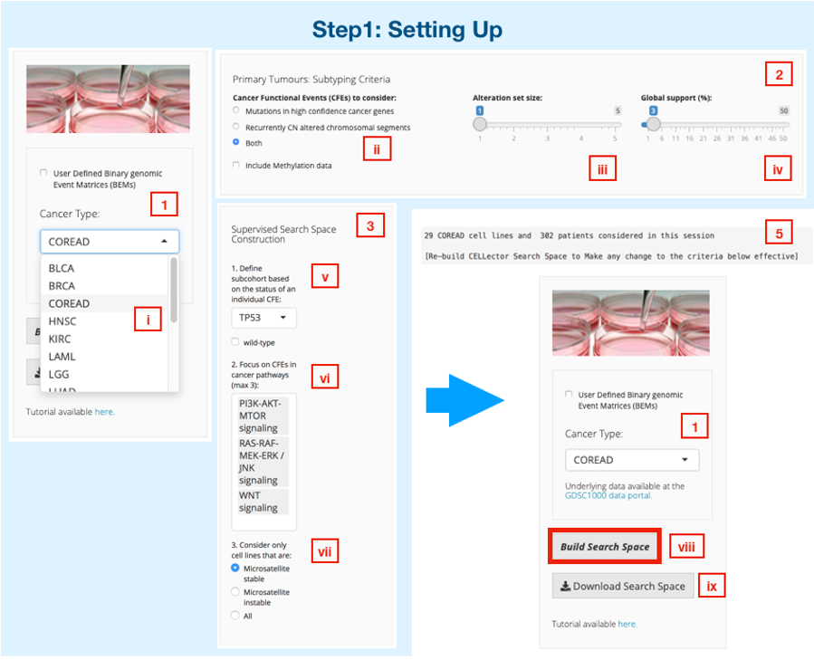

CELLector provides built-in genomics data for matching primary tumours and cell lines derived from 16 cancer types. To start, we select a cancer type of interest from a dropdown list (as shown above) or alternatively, we can upload our own reference data by ticking the *User Defined Binary genomic Event Matrices (BEMs)* box (as shown below). In this example case study, we select Colorectal Cancer (COREAD) (i) and we use the CELLector built-in data.

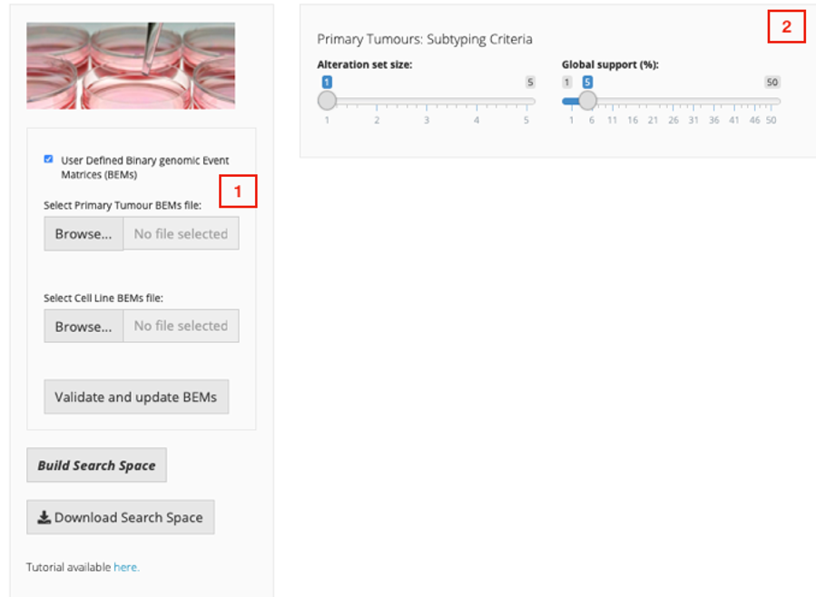

Next, we have to specify some additional parameters determining the way the CELLector search space is constructed, or use their default values. In this example case study, we want to account for the genomic diversity of the studied cohort based considering both somatic mutations and copy number alterations (ii). Alteration set size is set to 1 (default setting; iii), meaning that the algorithm looks for only one alteration at the time that is the most prevalent while recursively identified tumour subpopulations. If the alteration set size is set to 2 (max 5), then the algorithm looks for co-occurring combinations of two (up to 5) alterations at the time while recursively identified tumour subpopulations. Lastly, we specify that the genomic signatures (e.g. the combination of co-occurring genomic alterations) underlying the identified tumour subpopulations have to be prevalent in at least 3% of patients in the studied tumour cohort (iv). These steps (ii, iii and iv) are essential to build the CELLector search space and to subsequently map representative in vitro models on it. If no other criteria are specified, the analysis is executed on the whole cohort of COREAD tumours (n=517) and considering the entire set of COREAD cell lines (n=51) available in the CELLector built-in datasets. When user defined reference data (Box 1) is used, the following parameters: alteration set size and global support (Box 2) have to be specified before running the analysis (as shown above).

To flexibly tailor the model selection to the context of a specific study, users can reduce the tumour cohort to be analysed based on the status of an individual alteration (v), or alterations in cancer pathways (vi) or/and consider the microsatellite status of the cell lines (vii).

In this case study, we want to select cell lines that best represent a colorectal cancer patient sub-cohort that harbours TP53 mutation. In addition, models should harbour at least one alteration in the following signalling pathways: *PI3K-AKT-MTOR signalling*, *RAS-RAF-MEK_ERK/JNK signalling* and *WNT signalling* and are microsatellite stable.

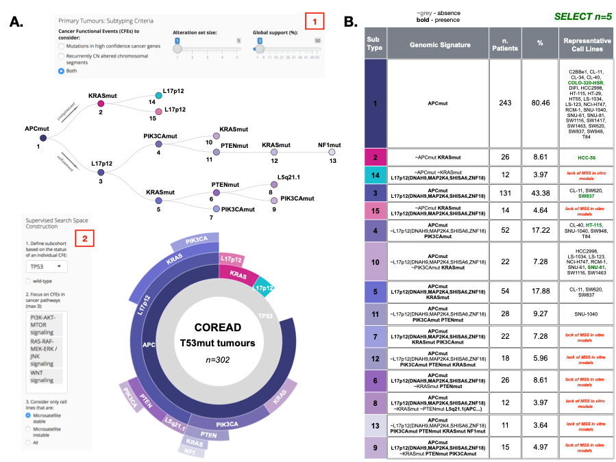

*Case Study Figure 1* **A.** Visual representation of the CELLector search space summarising the genomic heterogeneity of TP53 mutant colorectal (COREAD) tumours, considering both somatic mutations and copy number alterations in user-defined biological pathways (user interface box 1 and box 2). Each node of the binary tree (top) represents a tumour subpopulation associated with a genomic signature. The prevalence of the identified signatures, and their hierarchical co-occurrence is represented by the sunburst (below the tree). Each segment of the sunburst corresponds to a node in the tree and is color-coded accordingly. The CELLector search space is built using genomic characterisation of a cohort of 517 colorectal cancer patient available as a built-in dataset. First, the cohort is reduced to the 302 tumours harbouring TP53 mutations. CELLector then identifies 3 major molecular subpopulations characterised, respectively, by APC mutations, KRAS mutations, and loss of a segment of chromosome 17 (at the 17p12 loci) that collectively represent 93% (n=243+26+12 = 281) of the studied tumour cohort. The remaining 7% of the TP53 mutant tumours (n=21) do not fall into any of the identified molecular subpopulations thus are not represented in the CELLector search space. The largest molecular subpopulation (80.46%, n=243, harbouring TP53 and APC mutations) is assigned to the root of the search space (node 1, in purple). The second largest subpopulation (9%, n=26) is characterised by co-occurrence of TP53 and KRAS mutations in absence of APC mutations (node 2, in magenta), and the third largest subpopulation (4%, n=12) harbours TP53 mutations and the loss of 17p12 segment in the absence of both APC and KRAS mutations (node 14, in cyan). Each of these complementary tumour subpopulations are then further refined based on the prevalence of the remaining set of molecular alterations. This process runs recursively and stops when all molecular alteration sets with user-determined tumour prevalence (in this case 3%, user interface box 1) are defined. In this study case, a total number of 15 distinct tumour subpopulations with defined genomic signatures are identified, when considering the TP53 mutant tumour sub-cohort and alterations in the selected pathways. **B.** Cell Line Map table including microsatellite stable cell lines mirroring the genomic signatures of the TP53 mutant COREAD tumour subpopulations identified in the CELLector search space (user interface box 2). The Cell Map table uncovers the complete set of molecular alterations (e.g. genomic signatures) that characterise each tumour subpopulation. For example, the least prevalent TP53 mutant colorectal cancer subpopulation (node 13, 3.64% of patients) is characterised by co-occurring mutations in APC, PIK3CA, PTEN, KRAS and NF1 in the absence of 17p12 segment loss; this genomic signature is not mirrored by any of the considered microsatellite stable (MSS) colorectal cancer models. The representative cell lines are picked from each of the molecular tumour subpopulations starting with the most prevalent one. The models in green represent a possible choice of n-user-defined cell lines that could be selected in the presented case study.

#### Step 2: Exploring the search space

CELLector provides a range of visualisation tools enabling users to interactively explore the CELLector search space (e.g. the identified tumour subpopulations with defined genomic signature) and the cell line selection results (Box 6), shown in the below figure. These include a binary tree (A), a sunburst (B), a pie chart (C), a dot plot (D) and a cell line information table (E).

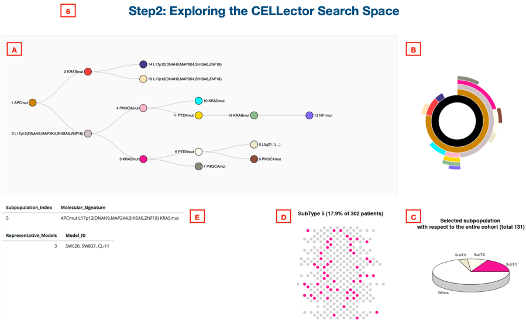

When the search space building is completed, a binary tree, which represents the genomic diversity of the examined patient cohort, pops up in the bottom of the page. The root of this tree represents the largest tumour subpopulation and it has two sibling nodes. The upper node represents a population that is complementary to that represented by the parent node, while the lower node represents a refinement of the parent subpopulation. This definition applies recursively to each node. To search space is also visualised as an interactiev sunburst that takes into account of the prevalence of the identified genomic signatures and their hierarchical co-occurrence (B). Users can interactively explore both tree and sunburs. In the tree, nodes with a bold circle are expandable (not shown). If clicking on a node, the tumour subpopulation information relating to this node is displayed (in the figure abow information relating to selected node 5, in magenta, are shown). The segments of the sunburst (B), dot plot (D) and pie chart (C), which correspond to selected tumour subpopulation, are color-coded accordingly. The molecular signature of a tumour subpopulation is also shown below the tree, together with information regarding the number and names of cell line models that mirror this signature (E). This example subpopulation (node 5, in magenta) is defined by a combination of co-occurring mutations in TP53, APC, KRAS and losses of the 17p12 genomic segment and covers 17.9% of TP53 mutated tumours (as shown in E and D). There are 3 cell line modeliing this molecular signature (SW620, SW837, CL-11, as shown in E).

#### Step 3: Selecting cell lines

The last step in the CELLector analysis, after constructing the search space (Step 1), consist of selecting a user defined number of representative cell line models (Box 7).

The list of possible model choices (in this case example, made of 5 cell lines) is downloaded into a user-specified directory by clicking on *CELLect Cell Lines*. The outputted file provides information regarding the prevalence of the tumour subpopulations represented by the selected modelwith corresponding genomic signatures. The *Cell lines SubTypes Map* can be also downloaded by clicking on the *Cell lines SubTypes Map* button. Finally, the user can score the representative ability of the cell lines by specifying how to weight the length of the signatures they account for and the size of the corresponding modeled patient sub-cohort (bottom of Box 7). Cell line scores are downloadable by clicking on *Score cell lines*.

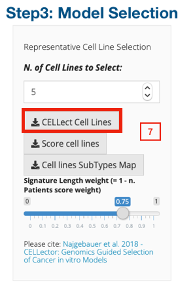

### Study case 2: Unsupervised selection of microsatellite stable cell lines best representing colorectal cancer patients

In this case study, we want to select 5 microsatellite stable cell lines capturing the genomic heterogeneity of a cohort of colorectal cancer patients, focusing on sets of somatic mutations that are prevalent in at least 5% of the considered patient cohort. Setting up and building the search space as for the previus study case, yields the summary results shown in the figure below.

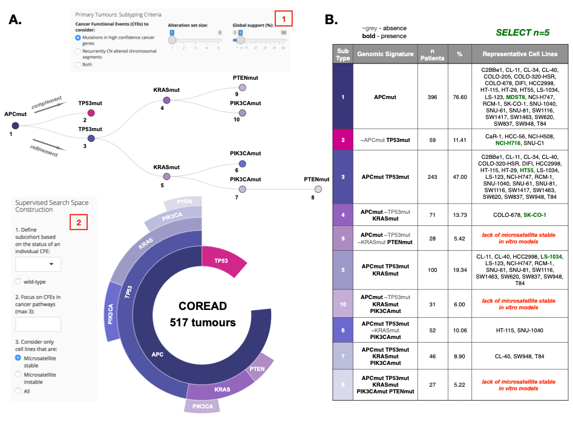

## Decoding identifiers of copy number alterations and hypermethylated gene promoters

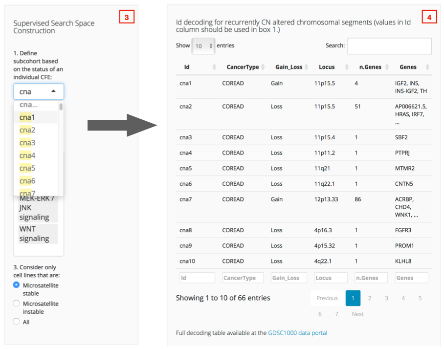

If a user wishes to include copy number alterations (can) or hypermethylation (hsm) in the analysis (Box 3: Supervised Search Space Construction), CELLector provides a look up tables to search for genes that are within recurrently copy number altered chromosomal segments (Box 4) or downstreaming hypermethylated gene promoters (table not shown).

## Building genomic binary event matrices (BEMs)

CELLector allowing assembling *de-novo* genomic binary event matrices from user defined genomic data, which can be used to perform CELLector analyses or with independent/external tools.

The *BEM Builder* page displays two panels, respectively for *Primary tumours* and *in-vitro models* (as shown below).

[figure not shown]

### Building BEMs for primary tumours

BEMs for primary tumours can be generated using CELLector built-in variant catalogues from the [TCGA](https://portal.gdc.cancer.gov/) (using curated data from Iorio *et al*. 2016) or user own reference data.

#### Using built-in genomic datasets from the TCGA

To generate tumour BEMs from built-in TCGA data user should select the *use curated TCGA data from Iorio et al. 2016* option (step 1) then select the cancer type of interest (step 2) then specify which genes and variants to consider (step 3). Supported options are *All* genes/variants, Iorio *et al*.2016’ drivers/variants (in this case a set of high-confidence cancer driver genes generated by the [intOGen](https://www.intogen.org/) pipeline will be used), *CMP drivers* (in this case high-confidence cancer driver genes used to annotate cell line genomic data on the [Cell Model Passport](https://cellmodelpassports.sanger.ac.uk/) and *User defined list*, for both genes and variants. Once all the parameters are specified, users shoul select the *BEM file format* (R object or .tsv) and click on *Make new BEM* (step 4). The information regarding the number of tumours and mutated genes used to generate the BEM will be displayed (as shown below), the BEM will be generated and saved to a user specified directory by clicking on on *Make new BEM* and then on *Save BEM* (step 5).

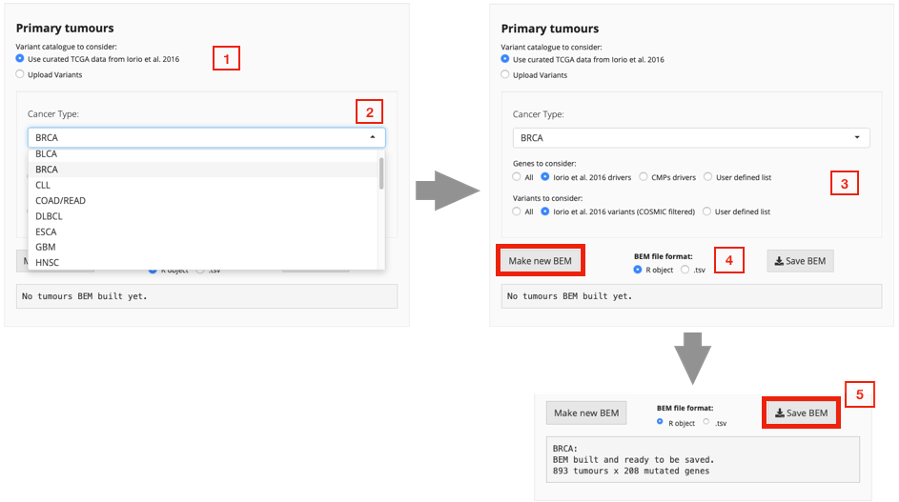

#### Using custom user-defined datasets

To generate tumour BEMs with custom user defined genomic data, users should select the *Upload Variants* option (step 1), then select a file with the variants (a tab delimited txt file with two columns, respectively for gene symbols and aminoacid substitutions) (step 2), the select the file format (R object or .tsv) and click on *Make new BEM* (step 3). The information regarding the number of tumours and mutated genes used to generate the BEM will displayed, the BEM generated, and saved to user specified directory by clicking on *Make new BEM* and then on *Save BEM* (step 4).

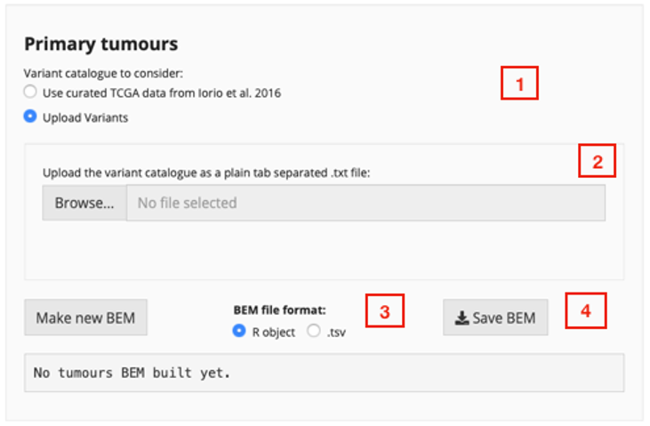

### Building BEMs for *in vitro* models

BEMs for in vitro models can be generated using variant catalogues from the [Cell Model Passport (CMPs)](https://cellmodelpassports.sanger.ac.uk/) or custom user-defined data.

#### Using data from the [*Cell Model Passport*](https://cellmodelpassports.sanger.ac.uk/)

To generate BEMs for in vitro models using variant catalogue from [Cell Model Passport (CMPs)](https://cellmodelpassports.sanger.ac.uk/), users should select the *use Variant Catalogue from Cell Model Passports (CMPs)* option (step 1) then specify what types of models they are interested in (step 2), based on parameters such as tissue of origin, cancer type and subtypes, age, ethnicity, ploidy etc. Infos on available models based on the selected parameters will be displayed on the top of the panel (step 3). The information regarding the number of tumours and mutated genes used to generate the BEM will displayed.

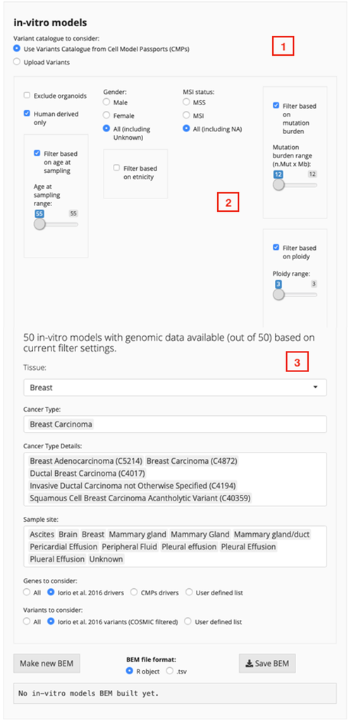

In the example below, we demonstrate how to generate models BEM for breast carcinoma cell lines derived from ascites, breast, mammary gland, peripheral fluid and pleural effusion. Applying these criteria, the number of available models is reduced from 50 (shown above, top panel step 3) to 10 (shown below, top panel step 3). Then we need to specify what genes and variants to consider. Supported options are (as for the previous cases) *All* genes/variants, *Iorio et al.2016* drivers/variants, Cell Model Passports *CMP drivers* and *User defined list* for both genes and variants. Once all the parameters are specified, select BEM file format (R object or .tsv) and click ‘Make new BEM’ (step 4). The information regarding the number of tumours and mutated genes used to generate the BEM will display in a box below (as shown below), the BEM generated, and saved to user specified directory by clicking on *Make new BEM* and then on *Save BEM* (step 4).

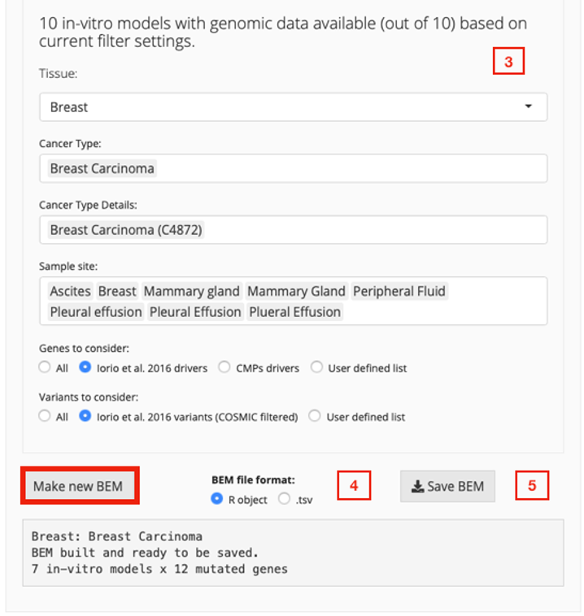

#### Using custom user-defined datasets

To generate in vitro model BEMs using custom user defined genomic data, user should select the *Upload Variants* option (step 1), then select the data from your local directory (step 2, formatted as specified in BEM for primary tumours section), then select the BEM file format (R object or .tsv) and then click on *Make new BEM* (step 3). The information regarding the number of models and mutated genes used to generate the BEM will displayed. Finally, once the BEM is generated, it is saved to user specified directory by clicking *Save BEM* (step 4).

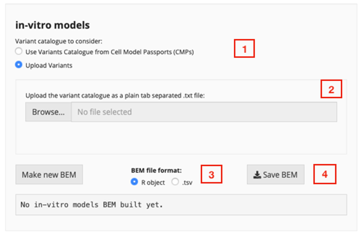

## Using the CELLector App locally

To use the CELLector App locally, its code should be downloaded as a single compressed folder from https://github.com/francescojm/CELLector_App/archive/master.zip. Once the folder has been downloaded, it should be uncompressed. Then [Rstudio](https://www.rstudio.com/) should be launched with the working directory set to the uncompressed folder with the CELLector App code (as shown in the figure below).

[figure not shown]

To launch the App, *global.R* file should be open and the *Run App* tab (in the top-right corner of the code window in Rstudio) should be clicked. All the required libraries will be automatically installed, alternatively they can be downloaded from (CRAN or Bioconductor) and installed manually as/if requested by the consolle.

Once the App is launched, we encourage to open it in a web-browser to optimize the visualisation capabilities, by clicking on the *Open in Browser* tab in the Rstudio App window.

[figure not shown]